# Analyzing Multiple Data Sets

## Objectives

- Explain what a `for` loop does.
- Correctly write for loops to repeat simple calculations.
- Trace changes to a loop variable as the loop runs.
- Trace changes to other variables as they are updated by a for loop.
- Explain what a list is.
- Create and index lists of simple values.
- Use a library function to get a list of filenames that match a simple wildcard pattern.
- Use a for loop to process multiple files.

## For Loops

```r
print_words = function(sentence) {
    print(sentence[1])
    print(sentence[2])
    print(sentence[3])
    print(sentence[4])
    print(sentence[5])
}

print_words(words)
```

but that's a bad approach for two reasons:

It doesn't scale: if we want to print the elements in a vector that's hundreds long, we'd be better off just typing them in.

It's fragile: if we give it a longer vector, it only prints part of the data, and if we give it a shorter one, it produces an error or gives us `NA` values because we're asking for elements that don't exist.

```r
hello <- c("I", "was", "here")
print_words(hello)
```

Here's a better approach:

```r
print_words <- function(sentence) {
    for (i in 1:length(sentence)) {
        print(sentence[i])
    }
}
```

This is shorter—certainly shorter than something that prints every character in a hundred-letter string—and more robust as well:

```r
print_words("oxygen")
```

The improved version of `print_words` uses a `for loop` to repeat an operation—in this case, printing—once for each thing in a collection. The general form of a loop is:

```r
for (variable in collection){
    do things with variable
}
```

We can call the loop variable anything we like, but there must be a curly brace `{` at the end of the line starting the loop, and we should indent the body of the loop.

Here's another loop that repeatedly updates a variable:

```r
len = 0
for (vowel in 1:nchar("aeiou")) {
    len = len + 1
    print(paste("There are", len, "vowels"))
}
```

It's worth tracing the execution of this little program step by step. Since there are five characters in 'aeiou', the `print` statement will be executed five times.

Note that a loop variable is just a variable that's being used to record progress in a loop. It still exists after the loop is over, and we can re-use variables previously defined as loop variables as well:

```r
letter = "z"
for (letter in 1:nchar("abc")) {
    print(substr("abc", letter, letter))
    print(paste("after the loop, letter is", letter))
}
```

### Challenges

1. R has a built-in function called `seq` that creates a list of numbers: `seq(3)` produces `[1] 1, 2, 3`, `seq(2, 5)` produces [1] 2, 3, 4, 5, and `seq(2, 10, 3)` produces `[1] 2, 5, 8`. Using `seq`, write a function that prints the *n* natural numbers:

```r
print_numbers <- function(N) {
    nseq <- seq(N)
    for (i in 1:length(nseq)) {
        print(nseq[i])
    }
}
```

1. Exponentiation is built into R: `2**4`. Write a function called expo that uses a loop to calculate the same result.

## Challenges

1. Write a function called total that calculates the sum of the values in a vector. (R has a built-in function called `sum` that does this for you. Please don't use it for this exercise.)

```r
total <- function(vector) {
    # calculates the sum of the values in a vector
    sum <- 0
    for (i in 1:length(vector)) {
        sum <- sum + vector[i]
    }
    sum
}
```

# Processing Multiple Files

We can use the same type of looping to process multiple files.

We have created a function called analyze that creates graphs of the minimum, average, and maximum daily inflammation rates for a single data set:

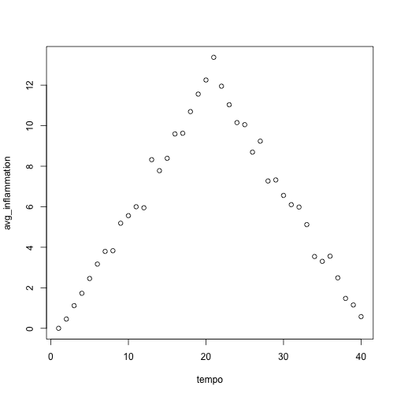

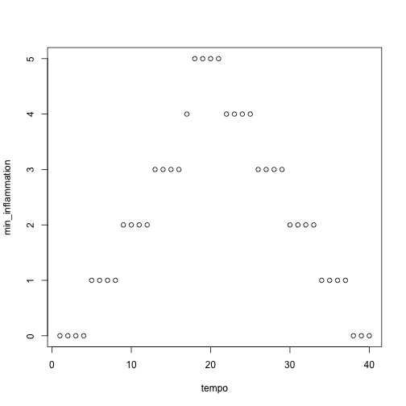

```r
analyze <- function(filename) {
    data <- read.csv(filename)

    avg_inflammation <- apply(data, 2, mean)
    max_inflammation <- apply(data, 2, max)
    min_inflammation <- apply(data, 2, min)
    tempo <- c(1:ncol(data))

    plot(tempo, avg_inflammation)
    plot(tempo, min_inflammation)
    plot(tempo, max_inflammation)
}

analyze("data/inflammation-01.csv")
```

We can use it to analyze other data sets one by one:

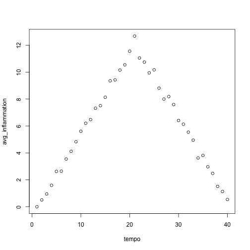

```r
analyze("data/inflammation-02.csv")
```

but we have a dozen data sets right now and more on the way. We want to create plots for all our data sets with a single statement. To do that, we need is a function that finds files whose names match a pattern. We provide those patterns as strings: the character * matches zero or more characters, while ? matches any one character. We can use this to get the names of all the R files we have created so far:

```r
list.files(pattern = "*.R")
```

or to get the names of all our CSV data files:

```r
list.files(pattern = "*.csv", recursive = TRUE)
```

As these examples show, `list.files()` result is a list of strings, which means we can loop over it to do something with each filename in turn. In our case, the “something” we want is our analyze function. Let's test it by analyzing the first three files in the list:

```r
filenames <- list.files(pattern = "*.csv", recursive = TRUE)
filenames <- filenames[1:3]

for (f in 1:length(filenames)) {
    print(filenames[f])
    analyze(filenames[f])
}
```

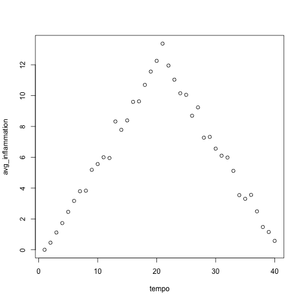

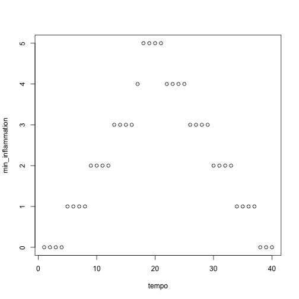

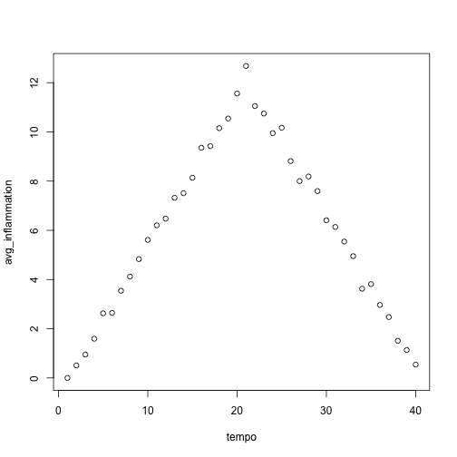

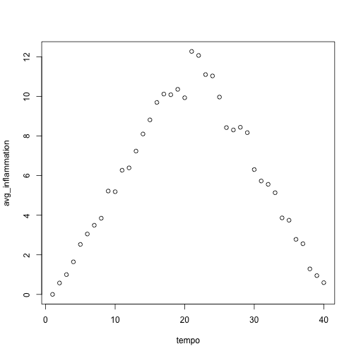

## Key Points

- Use `for variable in collection` to process the elements of a collection one at a time.
- The body of a for loop does not have to, but should be indented.
- Use `length(thing)` to determine the length of something that contains other values.
- c(value1, value2, value3, …) creates a vector
- Vectors are indexed and sliced in the same way as strings and arrays.
- vectors are mutable (i.e., their values can be changed in place).
- Use `list.files(pattern)` to create a list of files whose names match a pattern.
- Use `*` in a pattern to match zero or more characters.

## Next Steps

We have now solved our original problem: we can analyze any number of data files with a single command. More importantly, we have met two of the most important ideas in programming:

- Use functions to make code easier to re-use and easier to understand.
- Use vectors and arrays to store related values, and loops to repeat operations on them.

We have one more big idea to introduce… testing